# Stroke Fatality at Discharge: Binary Logistic Regression

- Show All Code
- Hide All Code
- View Source

RREAAPP workflow: Reason · Read · Explore · Assume · Apply · Assess · Present · Publish

Published

November 22, 2026

**Note**

**Teaching dataset.** `stroke-fatality-cooked2.dta` was modified by its author so that the patterns being taught show clearly. The results below illustrate method. They are not evidence about stroke care.

# 1 Reason

- **Research question:** which admission characteristics are associated with death before discharge among patients admitted with acute stroke?
- **Outcome:** `outcome`, status at discharge (alive = 0, **dead = 1**). The models estimate the **odds of death**.
- **Candidate predictors:** demographics (sex, age, ethnicity, marital status), earliest vital signs (GCS, SBP, DBP, heart rate), admission blood results (haemoglobin, platelets, WBC, sodium, potassium, blood sugar, urea), comorbidities (hypertension, diabetes, dyslipidaemia), referral source and stroke type.
- **Purpose:** to estimate adjusted associations (odds ratios), not to build a prediction tool. **GCS is a mediator** (stroke type → depressed consciousness → death), so it is examined in the univariable step but **left out of the multivariable model**.
- **Model:** binary logistic regression, main effects only (no interactions).

# 2 Read

## 2.1 Import with `haven`

```r
raw <- read_dta("../data/stroke-fatality-cooked2.dta")
dim(raw)
```

```
[1] 226  22
```

```r
tibble(variable = names(raw),
       label    = map_chr(raw, ~ attr(.x, "label") %||% ""),
       class    = map_chr(raw, ~ class(.x)[1]))
```

```
# A tibble: 22 × 3
   variable label                        class
   <chr>    <chr>                        <chr>
 1 rn       registration number          character
 2 sex      sex                          haven_labelled
 3 gcs      earliest Glasgow Coma Scale  numeric
 4 sbp      earliest systolic BP (mmHg)  numeric
 5 dbp      earliest diastolic BP (mmHg) numeric
 6 hr       heart rate                   numeric
 7 hb       hemoglobin                   numeric
 8 plat     platelet                     numeric
 9 wbc      total white cell count       numeric
10 na       natrium                      numeric
# ℹ 12 more rows
```

## 2.2 Fix variable names and codes

The names are renamed to descriptive snake_case, the labelled Stata variables are converted to factors, and reference categories are set. The raw file is never changed.

```r
stroke <- raw %>%
  zap_label() %>%
  rename(id = rn, heart_rate = hr, haemoglobin = hb, platelet = plat,
         sodium = na, potassium = potas, blood_sugar = cbs,
         married = maritalstat, referral = referralcase,
         stroke_type = stroketype) %>%
  mutate(across(where(is.labelled), as_factor)) %>%
  mutate(
    outcome     = fct_relevel(outcome, "alive"),
    sex         = fct_relevel(sex, "male"),
    stroke_type = fct_recode(stroke_type,
                             Ischaemic    = "CI (Ischaemic Stroke)",
                             Haemorrhagic = "Haemorrhagic Stroke") %>%
                  fct_relevel("Ischaemic"),
    referral    = fct_recode(referral, Hospital = "hospital",
                             `GP/Home` = "GP/Home/Missing") %>%
                  fct_relevel("Hospital"),
    across(c(hypertension, married, malay, diabetes, dyslipidaemia),
           ~ fct_relevel(.x, "no")),
    dead        = as.integer(outcome == "dead")      # numeric 0/1 copy
  ) %>%
  mutate(across(where(is.factor), fct_drop))

# variable labels for tables
var_labels <- list(
  sex = "Sex", age = "Age (years)", malay = "Malay ethnicity",
  married = "Married", gcs = "Glasgow Coma Scale", sbp = "Systolic BP (mmHg)",
  dbp = "Diastolic BP (mmHg)", heart_rate = "Heart rate (bpm)",
  haemoglobin = "Haemoglobin (g/dL)", platelet = "Platelet (×10⁹/L)",
  wbc = "White cell count (×10⁹/L)", sodium = "Sodium (mmol/L)",
  potassium = "Potassium (mmol/L)", blood_sugar = "Capillary blood sugar (mmol/L)",
  urea = "Urea (mmol/L)", hypertension = "Hypertension", diabetes = "Diabetes",
  dyslipidaemia = "Dyslipidaemia", referral = "Referral source",
  stroke_type = "Stroke type", outcome = "Outcome at discharge")

glimpse(stroke)
```

```
Rows: 226
Columns: 23
$ id            <chr> "A009511", "A010909", "A012903", "A015260", "A018618", "…
$ sex           <fct> female, male, male, female, female, male, female, female…
$ gcs           <dbl> 15, 3, 10, 10, 5, 15, 15, 15, 3, 15, 10, 9, 15, 15, 15, …
$ sbp           <dbl> 124, 198, 127, 173, 130, 143, 169, 188, 196, 125, 185, 1…
$ dbp           <dbl> 82, 130, 55, 79, 80, 93, 114, 85, 95, 76, 100, 82, 114, …
$ heart_rate    <dbl> 70, 114, 94, 81, 74, 98, 84, 83, 92, 87, 140, 62, 92, 67…
$ haemoglobin   <dbl> 13.2, 14.0, 15.1, 11.1, 13.4, 16.5, 14.0, 15.1, 13.9, 15…
$ platelet      <dbl> 107, 266, 158, 225, 273, 255, 220, 198, 273, 283, 452, 2…
$ wbc           <dbl> 6.5, 13.9, 12.0, 19.8, 7.5, 15.6, 8.0, 5.0, 10.5, 12.9, …
$ sodium        <dbl> 137, 132, 136, 143, 146, 139, 139, 144, 147, 133, 142, 1…
$ potassium     <dbl> 3.8, 4.0, 3.8, 3.5, 3.8, 3.5, 3.1, 3.8, 4.7, 3.9, 3.5, 5…
$ blood_sugar   <dbl> 11.7, 14.3, 5.0, 10.7, 10.0, 8.9, 4.9, 5.7, 7.2, 18.3, 1…
$ urea          <dbl> 13.2, 9.9, 5.8, 4.6, 3.0, 4.9, 4.7, 7.9, 11.6, 4.8, 13.7…
$ age           <dbl> 86, 67, 32, 59, 50, 67, 78, 74, 74, 42, 64, 46, 43, 51, …
$ outcome       <fct> alive, dead, dead, dead, dead, alive, alive, alive, dead…
$ hypertension  <fct> yes, yes, no, yes, no, yes, yes, yes, yes, no, yes, yes,…
$ married       <fct> yes, yes, yes, yes, yes, yes, yes, yes, yes, yes, yes, y…
$ malay         <fct> yes, yes, yes, yes, yes, yes, yes, yes, yes, yes, yes, y…
$ diabetes      <fct> yes, yes, no, yes, no, yes, no, no, no, yes, yes, yes, y…
$ dyslipidaemia <fct> no, no, no, no, no, no, no, no, no, yes, no, no, no, no,…
$ referral      <fct> GP/Home, GP/Home, Hospital, GP/Home, Hospital, GP/Home, …
$ stroke_type   <fct> Ischaemic, Haemorrhagic, Ischaemic, Ischaemic, Haemorrha…
$ dead          <int> 0, 1, 1, 1, 1, 0, 0, 0, 1, 0, 1, 1, 0, 0, 0, 0, 1, 0, 0,…
```

```r
count(stroke, outcome) %>% mutate(percent = round(100 * n / sum(n), 1))
```

```
# A tibble: 2 × 3
  outcome     n percent
  <fct>   <int>   <dbl>
1 alive     164    72.6
2 dead       62    27.4
```

```r
num_vars <- c("age", "gcs", "sbp", "dbp", "heart_rate", "haemoglobin", "platelet",
              "wbc", "sodium", "potassium", "blood_sugar", "urea")
cat_vars <- c("sex", "malay", "married", "hypertension", "diabetes",
              "dyslipidaemia", "referral", "stroke_type")
```

**Result.** 226 patients and 22 variables: 12 numeric, 8 categorical predictors, the outcome and an ID. 62 patients (27.4%) died before discharge.

# 3 Explore

## 3.1 Missing data

```r
stroke %>%
  summarise(across(everything(), ~ sum(is.na(.x)))) %>%
  pivot_longer(everything(), names_to = "variable", values_to = "n_missing") %>%
  arrange(desc(n_missing))
```

```
# A tibble: 23 × 2
   variable    n_missing
   <chr>           <int>
 1 id                  0
 2 sex                 0
 3 gcs                 0
 4 sbp                 0
 5 dbp                 0
 6 heart_rate          0
 7 haemoglobin         0
 8 platelet            0
 9 wbc                 0
10 sodium              0
# ℹ 13 more rows
```

**Result.** 0 missing values in total. **The dataset is complete.**

## 3.2 Possible errors in the data

Each numeric variable is checked against a plausible clinical range. The checks also cover duplicate IDs, DBP ≥ SBP, non-integer GCS and empty factor levels.

```r
ranges <- tribble(
  ~variable,     ~lower, ~upper,
  "age",             18,    110,
  "gcs",              3,     15,
  "sbp",             60,    300,
  "dbp",             30,    200,
  "heart_rate",      30,    220,
  "haemoglobin",      4,     22,
  "platelet",        10,   1000,
  "wbc",              1,     50,
  "sodium",         110,    170,
  "potassium",        2,      8,
  "blood_sugar",      1,     40,
  "urea",             1,     60)

range_check <- stroke %>%
  select(id, all_of(num_vars)) %>%
  pivot_longer(-id, names_to = "variable") %>%
  left_join(ranges, by = "variable") %>%
  filter(value < lower | value > upper)
range_check
```

```
# A tibble: 2 × 5
  id      variable value lower upper
  <chr>   <chr>    <dbl> <dbl> <dbl>
1 B165585 sodium     109   110   170
2 B486178 sodium     177   110   170
```

```r
tibble(
  check  = c("Duplicate IDs", "DBP >= SBP", "Non-integer GCS",
             "Values outside plausible range"),
  n_flagged = c(sum(duplicated(stroke$id)), sum(stroke$dbp >= stroke$sbp),
                sum(stroke$gcs != round(stroke$gcs)), nrow(range_check)))
```

```
# A tibble: 4 × 2
  check                          n_flagged
  <chr>                              <int>
1 Duplicate IDs                          0
2 DBP >= SBP                             0
3 Non-integer GCS                        0
4 Values outside plausible range         2
```

```r
map(stroke[cat_vars], table)   # check factor levels
```

```
$sex

  male female
    97    129

$malay

 no yes
 15 211

$married

 no yes
 21 205

$hypertension

 no yes
 70 156

$diabetes

 no yes
134  92

$dyslipidaemia

 no yes
198  28

$referral

Hospital  GP/Home
      87      139

$stroke_type

   Ischaemic Haemorrhagic
         149           77
```

**Result.** There are no duplicate IDs, no DBP ≥ SBP and no non-integer GCS. Every factor has only its expected levels; the “Other” stroke type in the Stata label has no patients. 2 value(s) fall outside the plausible ranges and are listed above. These are flagged for checking against the source records. **They are kept in the analysis, as agreed.**

## 3.3 Outliers (IQR rule)

```r
outliers <- stroke %>%
  select(id, all_of(num_vars)) %>%
  pivot_longer(-id, names_to = "variable") %>%
  group_by(variable) %>%
  mutate(q1 = quantile(value, 0.25), q3 = quantile(value, 0.75),
         iqr = q3 - q1,
         outlier = value < q1 - 1.5 * iqr | value > q3 + 1.5 * iqr) %>%
  ungroup()

outliers %>% group_by(variable) %>%
  summarise(min = min(value), q1 = first(q1), median = median(value),
            q3 = first(q3), max = max(value), n_outliers = sum(outlier)) %>%
  arrange(desc(n_outliers))
```

```
# A tibble: 12 × 7
   variable      min    q1 median     q3   max n_outliers
   <chr>       <dbl> <dbl>  <dbl>  <dbl> <dbl>      <int>
 1 sodium      109   136   138    140    177           14
 2 urea          2.3   4.8   6.5    9.23  41           14
 3 age          20    52    61     68.8   94            7
 4 blood_sugar   2.4   6.4   8.1   12.3   26.7          7
 5 platelet     43   186.  234.   273    459            6
 6 potassium     2.3   3.5   3.85   4.2    5.7          6
 7 heart_rate   37    68    80.5   95    174            5
 8 haemoglobin   5.3  11.6  13.4   14.6   19.7          4
 9 wbc           4.2   7.5   9.9   12.6   27            4
10 dbp          42    79.2  91    104    160            3
11 sbp          75   143   161    186    290            2
12 gcs           3    10    15     15     15            0
```

```r
outliers %>% filter(outlier) %>% select(id, variable, value) %>%
  arrange(variable, value) %>% print(n = Inf)
```

```
# A tibble: 72 × 3
   id      variable    value
   <chr>   <chr>       <dbl>
 1 B421731 age          20
 2 B404097 age          21
 3 B330602 age          24
 4 B457723 age          24
 5 A071789 age          25
 6 A823086 age          94
 7 B098506 age          94
 8 B483525 blood_sugar  22.2
 9 B472708 blood_sugar  22.3
10 A074890 blood_sugar  24
11 A869024 blood_sugar  24
12 B464904 blood_sugar  24.3
```

[output cut: 60 more lines]

**Result.** 72 values in 52 patients fall outside 1.5 × IQR. Sodium and urea have the most. Most of these are clinically plausible extremes for acutely ill stroke patients, such as hyponatraemia or raised urea, rather than errors. **No records are removed.**

## 3.4 Numeric variables: histograms and boxplots

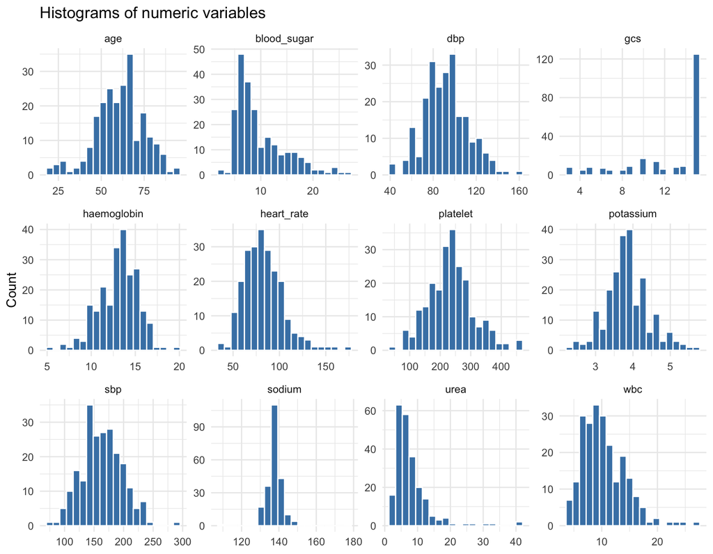

```r
stroke_long <- stroke %>%
  select(outcome, all_of(num_vars)) %>%
  pivot_longer(-outcome, names_to = "variable")

ggplot(stroke_long, aes(value)) +
  geom_histogram(bins = 20, fill = "steelblue", colour = "white") +
  facet_wrap(~ variable, scales = "free", ncol = 4) +
  labs(title = "Histograms of numeric variables", x = NULL, y = "Count")
```

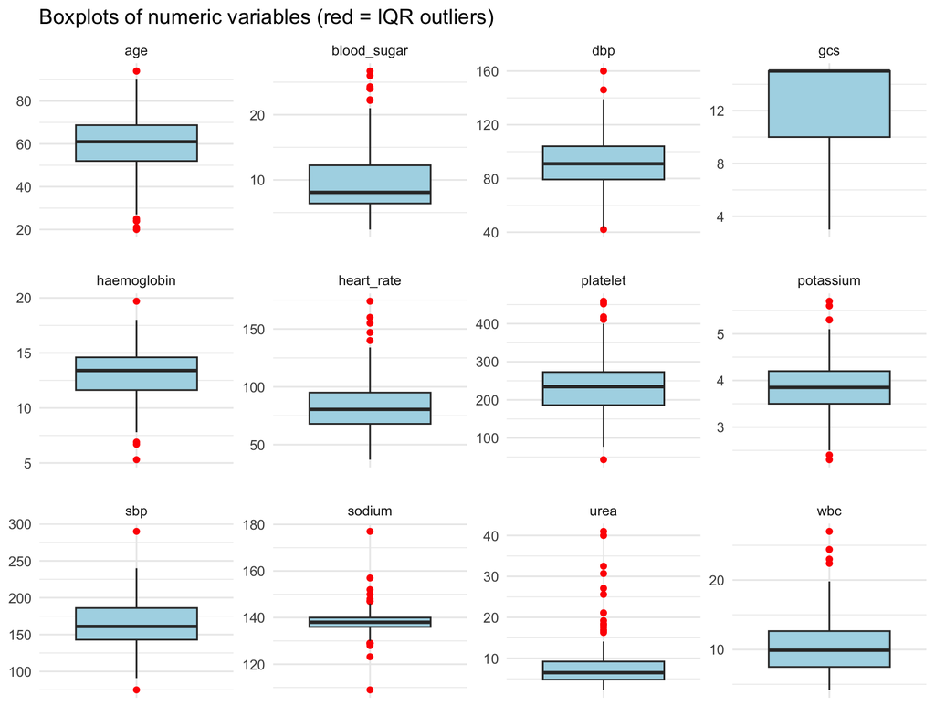

```r
ggplot(stroke_long, aes(x = "", y = value)) +
  geom_boxplot(fill = "lightblue", outlier.colour = "red") +
  facet_wrap(~ variable, scales = "free", ncol = 4) +
  labs(title = "Boxplots of numeric variables (red = IQR outliers)", x = NULL, y = NULL)
```

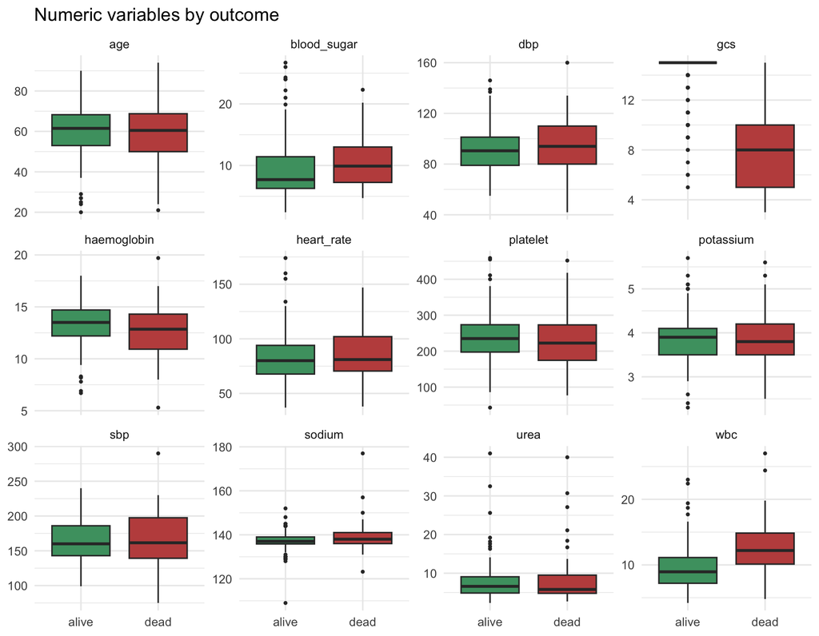

```r
ggplot(stroke_long, aes(outcome, value, fill = outcome)) +
  geom_boxplot(outlier.size = 0.8) +
  facet_wrap(~ variable, scales = "free_y", ncol = 4) +
  scale_fill_manual(values = c(alive = "#4C9F70", dead = "#C0504D")) +
  labs(title = "Numeric variables by outcome", x = NULL, y = NULL) +
  theme(legend.position = "none")
```

**Interpretation.** GCS is strongly left-skewed: most patients score 15. Urea, blood sugar and WBC are right-skewed. Deaths have visibly lower GCS and higher WBC.

## 3.5 Categorical variables: bar charts

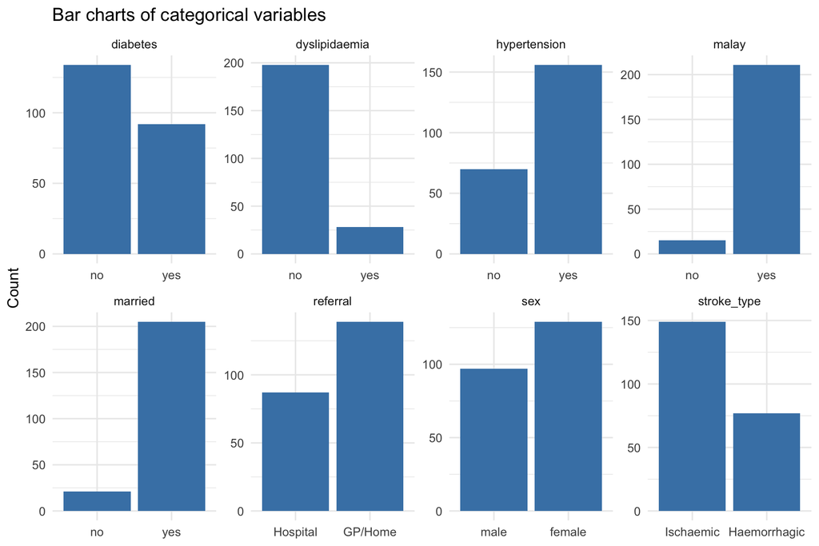

```r
cat_long <- stroke %>%
  select(outcome, all_of(cat_vars)) %>%
  pivot_longer(-outcome, names_to = "variable", values_to = "level")

ggplot(cat_long, aes(level)) +
  geom_bar(fill = "steelblue") +
  facet_wrap(~ variable, scales = "free", ncol = 4) +
  labs(title = "Bar charts of categorical variables", x = NULL, y = "Count")
```

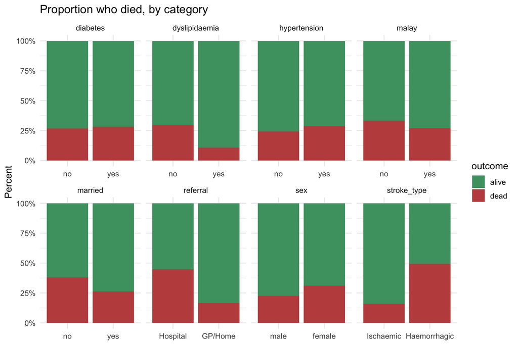

```r
ggplot(cat_long, aes(level, fill = outcome)) +
  geom_bar(position = "fill") +
  facet_wrap(~ variable, scales = "free_x", ncol = 4) +
  scale_fill_manual(values = c(alive = "#4C9F70", dead = "#C0504D")) +
  scale_y_continuous(labels = scales::percent) +
  labs(title = "Proportion who died, by category", x = NULL, y = "Percent")
```

## 3.6 Descriptive table (gtsummary)

```r
stroke %>%
  select(-id, -dead) %>%
  tbl_summary(by = outcome, label = var_labels,
              statistic = all_continuous() ~ "{median} ({p25}, {p75})") %>%
  add_overall() %>%
  add_p() %>%
  bold_p() %>%
  modify_spanning_header(all_stat_cols(FALSE) ~ "**Outcome at discharge**")
```

Table 1: Table 1. Patient characteristics by outcome at discharge

| **Characteristic** | **Overall** N = 226<sup>1</sup> | **Outcome at discharge** **alive** N = 164<sup>1</sup> | **Outcome at discharge** **dead** N = 62<sup>1</sup> | **p-value**<sup>2</sup> |  |
| --- | --- | --- | --- | --- | --- |
| Sex |  |  |  |  | 0.2 |
| male | 97 (43%) | 75 (46%) | 22 (35%) |  |  |
| female | 129 (57%) | 89 (54%) | 40 (65%) |  |  |
| Glasgow Coma Scale | 15.0 (10.0, 15.0) | 15.0 (15.0, 15.0) | 8.0 (5.0, 10.0) | <0.001 |  |
| Systolic BP (mmHg) | 161 (143, 186) | 160 (143, 186) | 162 (139, 198) | 0.8 |  |
| Diastolic BP (mmHg) | 91 (79, 104) | 91 (79, 102) | 94 (80, 110) | 0.4 |  |
| Heart rate (bpm) | 81 (68, 95) | 80 (68, 94) | 81 (70, 102) | 0.055 |  |
| Haemoglobin (g/dL) | 13.40 (11.60, 14.60) | 13.50 (12.20, 14.70) | 12.85 (10.90, 14.30) | 0.061 |  |
| Platelet (×10⁹/L) | 235 (186, 273) | 235 (197, 274) | 223 (174, 273) | 0.4 |  |
| White cell count (×10⁹/L) | 9.9 (7.5, 12.7) | 9.0 (7.2, 11.2) | 12.2 (10.1, 14.9) | <0.001 |  |
| Sodium (mmol/L) | 138.0 (136.0, 140.0) | 137.0 (135.7, 139.0) | 138.0 (136.0, 141.0) | 0.2 |  |
| Potassium (mmol/L) | 3.85 (3.50, 4.20) | 3.90 (3.50, 4.10) | 3.80 (3.50, 4.20) | 0.7 |  |
| Capillary blood sugar (mmol/L) | 8.1 (6.4, 12.3) | 7.7 (6.3, 11.5) | 9.9 (7.2, 13.0) | 0.008 |  |
| Urea (mmol/L) | 6.5 (4.8, 9.3) | 6.6 (4.9, 9.2) | 5.8 (4.8, 9.7) | 0.7 |  |
| Age (years) | 61 (52, 69) | 62 (53, 69) | 61 (50, 69) | 0.8 |  |
| Hypertension | 156 (69%) | 111 (68%) | 45 (73%) | 0.5 |  |
| Married | 205 (91%) | 151 (92%) | 54 (87%) | 0.3 |  |
| Malay ethnicity | 211 (93%) | 154 (94%) | 57 (92%) | 0.6 |  |
| Diabetes | 92 (41%) | 66 (40%) | 26 (42%) | 0.8 |  |
| Dyslipidaemia | 28 (12%) | 25 (15%) | 3 (4.8%) | 0.034 |  |
| Referral source |  |  |  | <0.001 |  |
| Hospital | 87 (38%) | 48 (29%) | 39 (63%) |  |  |
| GP/Home | 139 (62%) | 116 (71%) | 23 (37%) |  |  |
| Stroke type |  |  |  | <0.001 |  |
| Ischaemic | 149 (66%) | 125 (76%) | 24 (39%) |  |  |
| Haemorrhagic | 77 (34%) | 39 (24%) | 38 (61%) |  |  |

<sup>1</sup> n (%); Median (Q1, Q3)  
<sup>2</sup> Pearson’s Chi-squared test; Wilcoxon rank sum test; Fisher’s exact test

# 4 Assume

| Assumption | How it is checked |
| --- | --- |
| **Binomial distribution** of the outcome | The outcome is binary (dead/alive), so it is modelled with `family = binomial(link = "logit")` |
| **Independent observations** | One record per admission; no duplicate IDs (Section 3.2) |
| **Linear in the logit** for numeric predictors | Empirical logits by quartile and an LRT for an added quadratic term (Section 5.4) |
| **Model correctly specified** | Purposeful selection, no omitted confounders, Hosmer–Lemeshow test and residual diagnostics (Section 6) |
| No multicollinearity | Variance inflation factor (VIF) below 5 (Section 5.4) |
| Enough events | 62 deaths; about 10 events per parameter allows roughly 6 parameters |

```r
table(stroke$outcome, stroke$dead)   # confirms 0/1 coding of the event
```

```
          0   1
  alive 164   0
  dead    0  62
```

# 5 Apply

## 5.1 Univariable logistic regression

Each candidate predictor is fitted alone: `glm(outcome ~ x, family = binomial)`. The p-value is from the likelihood ratio test (LRT) against the intercept-only model.

```r
candidates <- c(num_vars, cat_vars)
m_null <- glm(outcome ~ 1, data = stroke, family = binomial)

uni <- map_dfr(candidates, function(v) {
  m   <- glm(reformulate(v, "outcome"), data = stroke, family = binomial)
  lrt <- anova(m_null, m, test = "LRT")
  tidy(m, conf.int = TRUE) %>%
    filter(term != "(Intercept)") %>%
    mutate(variable = v, lrt_chisq = lrt$Deviance[2], lrt_p = lrt$`Pr(>Chi)`[2])
}) %>%
  transmute(variable, term,
            beta = estimate, beta_low = conf.low, beta_high = conf.high,
            OR = exp(estimate), OR_low = exp(conf.low), OR_high = exp(conf.high),
            wald_p = p.value, lrt_chisq, lrt_p) %>%
  arrange(lrt_p)

uni %>% mutate(across(where(is.numeric), ~ signif(.x, 3))) %>% print(n = Inf)
```

```
# A tibble: 20 × 11
   variable      term      beta beta_low beta_high    OR OR_low OR_high   wald_p
   <chr>         <chr>    <dbl>    <dbl>     <dbl> <dbl>  <dbl>   <dbl>    <dbl>
 1 gcs           gcs   -6.34e-1 -8.11e-1  -0.488   0.53  0.444    0.614 9.98e-15
 2 wbc           wbc    2.15e-1  1.32e-1   0.307   1.24  1.14     1.36  1.27e- 6
 3 stroke_type   stro…  1.62e+0  1.01e+0   2.26    5.07  2.74     9.59  3.48e- 7
 4 referral      refe… -1.41e+0 -2.04e+0  -0.804   0.244 0.13     0.448 7.04e- 6
 5 sodium        sodi…  7.21e-2  1.27e-2   0.141   1.07  1.01     1.15  2.69e- 2
 6 dyslipidaemia dysl… -1.26e+0 -2.73e+0  -0.167   0.283 0.0655   0.846 4.51e- 2
 7 heart_rate    hear…  1.3 e-2 -5.92e-4   0.0267  1.01  0.999    1.03  6.09e- 2
 8 haemoglobin   haem… -1.23e-1 -2.57e-1   0.00829 0.884 0.773    1.01  6.71e- 2
 9 sex           sexf…  4.27e-1 -1.7 e-1   1.04    1.53  0.844    2.84  1.66e- 1
10 blood_sugar   bloo…  3.82e-2 -2.21e-2   0.0973  1.04  0.978    1.1   2.07e- 1
11 married       marr… -5.43e-1 -1.46e+0   0.431   0.581 0.232    1.54  2.55e- 1
12 dbp           dbp    5.89e-3 -8.75e-3   0.0206  1.01  0.991    1.02  4.29e- 1
13 urea          urea   2.01e-2 -3.34e-2   0.0706  1.02  0.967    1.07  4.37e- 1
14 hypertension  hype…  2.34e-1 -4   e-1   0.9     1.26  0.671    2.46  4.78e- 1
15 platelet      plat… -1.32e-3 -5.39e-3   0.00265 0.999 0.995    1     5.19e- 1
16 malay         mala… -3.01e-1 -1.38e+0   0.901   0.74  0.252    2.46  5.97e- 1
17 age           age   -2.74e-3 -2.37e-2   0.0184  0.997 0.977    1.02  7.97e- 1
18 diabetes      diab…  6.99e-2 -5.29e-1   0.661   1.07  0.589    1.94  8.17e- 1
19 sbp           sbp    9.51e-4 -7.63e-3   0.00948 1     0.992    1.01  8.27e- 1
20 potassium     pota… -5.26e-2 -5.75e-1   0.462   0.949 0.563    1.59  8.42e- 1
# ℹ 2 more variables: lrt_chisq <dbl>, lrt_p <dbl>
```

## 5.2 Identify possible independent variables

Rules from purposeful selection:

1. Carry forward variables with univariable LRT **p < 0.25**.
2. **Exclude GCS**, a mediator on the causal pathway (see Reason).
3. **Keep sex and age** as standard demographic adjustments, whatever their p-value.

```r
screen <- uni %>% distinct(variable, lrt_p) %>%
  mutate(p_lt_0.25 = lrt_p < 0.25,
         decision = case_when(
           variable == "gcs"           ~ "Excluded: mediator",
           variable %in% c("sex", "age") ~ "Included: demographic adjustment",
           p_lt_0.25                   ~ "Included: p < 0.25",
           TRUE                        ~ "Not carried forward"))
screen %>% mutate(lrt_p = signif(lrt_p, 3)) %>% print(n = Inf)
```

```
# A tibble: 20 × 4
   variable         lrt_p p_lt_0.25 decision
   <chr>            <dbl> <lgl>     <chr>
 1 gcs           1.83e-31 TRUE      Excluded: mediator
 2 wbc           1.06e- 7 TRUE      Included: p < 0.25
 3 stroke_type   1.76e- 7 TRUE      Included: p < 0.25
 4 referral      4.21e- 6 TRUE      Included: p < 0.25
 5 sodium        1.63e- 2 TRUE      Included: p < 0.25
 6 dyslipidaemia 2.17e- 2 TRUE      Included: p < 0.25
 7 heart_rate    6.08e- 2 TRUE      Included: p < 0.25
 8 haemoglobin   6.62e- 2 TRUE      Included: p < 0.25
 9 sex           1.62e- 1 TRUE      Included: demographic adjustment
10 blood_sugar   2.11e- 1 TRUE      Included: p < 0.25
11 married       2.64e- 1 FALSE     Not carried forward
12 dbp           4.29e- 1 FALSE     Not carried forward
13 urea          4.45e- 1 FALSE     Not carried forward
14 hypertension  4.74e- 1 FALSE     Not carried forward
15 platelet      5.18e- 1 FALSE     Not carried forward
16 malay         6.03e- 1 FALSE     Not carried forward
17 age           7.97e- 1 FALSE     Included: demographic adjustment
18 diabetes      8.18e- 1 FALSE     Not carried forward
19 sbp           8.27e- 1 FALSE     Not carried forward
20 potassium     8.42e- 1 FALSE     Not carried forward
```

```r
selected <- screen %>% filter(str_starts(decision, "Included")) %>% pull(variable)
selected
```

```
 [1] "wbc"           "stroke_type"   "referral"      "sodium"
 [5] "dyslipidaemia" "heart_rate"    "haemoglobin"   "sex"
 [9] "blood_sugar"   "age"
```

## 5.3 Multivariable logistic regression (main effects, no interaction)

**Step 1: full model** with all selected variables.

```r
m_full <- glm(reformulate(selected, "outcome"), data = stroke, family = binomial)
tidy(m_full, exponentiate = TRUE, conf.int = TRUE) %>%
  mutate(across(where(is.numeric), ~ round(.x, 3)))
```

```
# A tibble: 11 × 7
   term                  estimate std.error statistic p.value conf.low conf.high
   <chr>                    <dbl>     <dbl>     <dbl>   <dbl>    <dbl>     <dbl>
 1 (Intercept)              0         5.80     -1.60    0.11     0         4.11
 2 wbc                      1.17      0.051     3.03    0.002    1.06      1.29
 3 stroke_typeHaemorrha…    2.44      0.386     2.31    0.021    1.14      5.24
 4 referralGP/Home          0.395     0.378    -2.46    0.014    0.186     0.826
 5 sodium                   1.04      0.041     0.886   0.375    0.961     1.13
 6 dyslipidaemiayes         0.406     0.751    -1.2     0.23     0.077     1.57
 7 heart_rate               1.01      0.008     1.13    0.26     0.993     1.03
 8 haemoglobin              0.952     0.081    -0.61    0.542    0.812     1.12
 9 sexfemale                1.11      0.367     0.29    0.772    0.542     2.30
10 blood_sugar              1.06      0.046     1.30    0.195    0.968     1.16
11 age                      1.02      0.013     1.31    0.191    0.992     1.04
```

**Step 2: backward elimination.** At each step the variable with the largest LRT p-value (> 0.05) is removed. Sex and age are kept as forced adjustments. Before a removal is accepted, the coefficients of the variables that are significant in the current model are checked. If any of them changes by more than 20%, the removed variable is a **confounder** and goes back in.

```r
forced <- c("sex", "age")
m_cur  <- m_full
log_steps <- list()
repeat {
  dr <- drop1(m_cur, test = "LRT") %>% as.data.frame() %>%
    rownames_to_column("variable") %>% filter(variable != "<none>")
  cand <- dr %>% filter(!variable %in% c(forced, unlist(map(log_steps, "kept")))) %>%
    arrange(desc(`Pr(>Chi)`)) %>% slice(1)
  if (nrow(cand) == 0 || cand$`Pr(>Chi)` < 0.05) break
  m_try <- update(m_cur, as.formula(paste(". ~ . -", cand$variable)))
  sig_terms <- tidy(m_cur) %>% filter(term != "(Intercept)", p.value < 0.05) %>% pull(term)
  sig_terms <- intersect(sig_terms, names(coef(m_try)))
  pct <- abs((coef(m_try)[sig_terms] - coef(m_cur)[sig_terms]) / coef(m_cur)[sig_terms]) * 100
  confounder <- length(pct) > 0 && max(pct) > 20
  log_steps[[length(log_steps) + 1]] <- tibble(
    step = length(log_steps) + 1, variable = cand$variable,
    lrt_p = round(cand$`Pr(>Chi)`, 3),
    max_change_pct = round(if (length(pct)) max(pct) else 0, 1),
    action = if (confounder) "kept (confounder)" else "removed",
    kept = if (confounder) cand$variable else NA_character_)
  if (!confounder) m_cur <- m_try
}
bind_rows(log_steps) %>% select(-kept)
```

```
# A tibble: 5 × 5
   step variable      lrt_p max_change_pct action
  <dbl> <chr>         <dbl>          <dbl> <chr>
1     1 haemoglobin   0.543            2.8 removed
2     2 sodium        0.357            7.2 removed
3     3 blood_sugar   0.296            6.7 removed
4     4 dyslipidaemia 0.33             5.8 removed
5     5 heart_rate    0.16             6.9 removed
```

```r
m_prelim <- m_cur
formula(m_prelim)
```

```
outcome ~ wbc + stroke_type + referral + sex + age
```

**Step 3: add back excluded variables one at a time** to check whether any becomes significant or acts as a confounder.

```r
excluded <- setdiff(candidates, c(all.vars(formula(m_prelim))[-1], "gcs"))
key_terms <- tidy(m_prelim) %>% filter(term != "(Intercept)", p.value < 0.05) %>% pull(term)
map_dfr(excluded, function(v) {
  m_add <- update(m_prelim, as.formula(paste(". ~ . +", v)))
  lrt <- anova(m_prelim, m_add, test = "LRT")
  pct <- abs((coef(m_add)[key_terms] - coef(m_prelim)[key_terms]) / coef(m_prelim)[key_terms]) * 100
  tibble(variable = v, lrt_p = round(lrt$`Pr(>Chi)`[2], 3),
         max_change_pct = round(max(pct), 1))
}) %>% arrange(lrt_p)
```

```
# A tibble: 14 × 3
   variable      lrt_p max_change_pct
   <chr>         <dbl>          <dbl>
 1 heart_rate    0.16             7.5
 2 dbp           0.294            4.8
 3 dyslipidaemia 0.319            5.4
 4 blood_sugar   0.362            7.1
 5 potassium     0.475            2.1
 6 sodium        0.496            3.9
 7 urea          0.517            1.6
 8 malay         0.544            0.9
 9 hypertension  0.577            2.6
10 haemoglobin   0.62             2.3
11 platelet      0.72             1.8
12 diabetes      0.78             0.9
13 sbp           0.839            0.6
14 married       0.881            0.3
```

## 5.4 Linearity in the logit and multicollinearity

```r
num_in_model <- intersect(num_vars, all.vars(formula(m_prelim)))

# (a) empirical logits by quartile
map_dfr(num_in_model, function(v) {
  stroke %>% mutate(q = cut_number(.data[[v]], 4)) %>%
    group_by(q) %>%
    summarise(n = n(), died = sum(dead), .groups = "drop") %>%
    mutate(variable = v, emp_logit = log((died + 0.5) / (n - died + 0.5)))
}) %>% mutate(emp_logit = round(emp_logit, 3)) %>% select(variable, everything())
```

```
# A tibble: 8 × 5
  variable q              n  died emp_logit
  <chr>    <fct>      <int> <int>     <dbl>
1 age      [20,52]       58    19    -0.706
2 age      (52,61]       56    13    -1.17
3 age      (61,68.8]     55    14    -1.05
4 age      (68.8,94]     57    16    -0.922
5 wbc      [4.2,7.5]     58     6    -2.09
6 wbc      (7.5,9.9]     58     8    -1.78
7 wbc      (9.9,12.6]    53    19    -0.571
8 wbc      (12.6,27]     57    29     0.034
```

```r
# (b) LRT for an added quadratic term
map_dfr(num_in_model, function(v) {
  m_q <- update(m_prelim, as.formula(paste0(". ~ . + I(", v, "^2)")))
  tibble(variable = v, quad_lrt_p = round(anova(m_prelim, m_q, test = "LRT")$`Pr(>Chi)`[2], 3))
})
```

```
# A tibble: 2 × 2
  variable quad_lrt_p
  <chr>         <dbl>
1 age           0.162
2 wbc           0.22
```

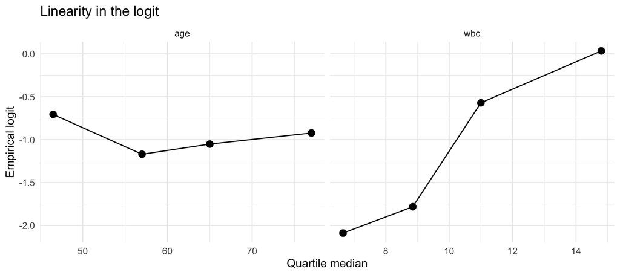

```r
map_dfr(num_in_model, function(v) {
  stroke %>% mutate(q = cut_number(.data[[v]], 4)) %>% group_by(q) %>%
    summarise(mid = median(.data[[v]]), n = n(), died = sum(dead), .groups = "drop") %>%
    mutate(variable = v, emp_logit = log((died + 0.5) / (n - died + 0.5)))
}) %>%
  ggplot(aes(mid, emp_logit)) + geom_point(size = 3) + geom_line() +
  facet_wrap(~ variable, scales = "free_x") +
  labs(x = "Quartile median", y = "Empirical logit", title = "Linearity in the logit")
```

```r
vif(m_prelim)
```

```
        wbc stroke_type    referral         sex         age
   1.110111    1.198231    1.142099    1.014188    1.098644
```

**Result.** For WBC, the empirical logits rise steadily across the quartiles. For age they are fairly flat and irregular, which fits its weak association with death. Neither quadratic term is significant (p > 0.05), so the **linear-in-the-logit assumption is reasonable** and both variables stay in as linear terms. All VIFs are close to 1, so there is no multicollinearity.

## 5.5 Final model

```r
m_final <- m_prelim
summary(m_final)
```

```
Call:
glm(formula = outcome ~ wbc + stroke_type + referral + sex +
    age, family = binomial, data = stroke)

Coefficients:
                        Estimate Std. Error z value Pr(>|z|)
(Intercept)             -4.05317    1.08769  -3.726 0.000194 ***
wbc                      0.18309    0.04862   3.766 0.000166 ***
stroke_typeHaemorrhagic  0.94203    0.37133   2.537 0.011183 *
referralGP/Home         -0.93479    0.36306  -2.575 0.010032 *
sexfemale                0.20896    0.35218   0.593 0.552964
age                      0.01707    0.01251   1.365 0.172364
---
Signif. codes:  0 '***' 0.001 '**' 0.01 '*' 0.05 '.' 0.1 ' ' 1

(Dispersion parameter for binomial family taken to be 1)

    Null deviance: 265.56  on 225  degrees of freedom
Residual deviance: 214.17  on 220  degrees of freedom
AIC: 226.17

Number of Fisher Scoring iterations: 4
```

```r
glance(m_final)
```

```
# A tibble: 1 × 8
  null.deviance df.null logLik   AIC   BIC deviance df.residual  nobs
          <dbl>   <int>  <dbl> <dbl> <dbl>    <dbl>       <int> <int>
1          266.     225  -107.  226.  247.     214.         220   226
```

```r
anova(m_null, m_final, test = "LRT")   # overall model test
```

```
Analysis of Deviance Table

Model 1: outcome ~ 1
Model 2: outcome ~ wbc + stroke_type + referral + sex + age
  Resid. Df Resid. Dev Df Deviance  Pr(>Chi)
1       225     265.56
2       220     214.17  5   51.394 7.181e-10 ***
---
Signif. codes:  0 '***' 0.001 '**' 0.01 '*' 0.05 '.' 0.1 ' ' 1
```

**Final model:** outcome ~ wbc + stroke_type + referral + sex + age. The model is highly significant overall: G = 51.39 on 5 df, p < 0.001.

# 6 Assess

## 6.1 Goodness of fit: Hosmer–Lemeshow test

```r
hl <- map_dfr(c(10, 8, 6), function(g) {
  h <- hoslem.test(stroke$dead, fitted(m_final), g = g)
  tibble(groups = g, C_hat = round(unname(h$statistic), 3),
         df = unname(h$parameter), p_value = round(h$p.value, 4))
})
hl
```

```
# A tibble: 3 × 4
  groups C_hat    df p_value
   <dbl> <dbl> <dbl>   <dbl>
1     10  13.1     8  0.107
2      8  14.1     6  0.0289
3      6  13.6     4  0.0085
```

```r
h10 <- hoslem.test(stroke$dead, fitted(m_final), g = 10)
cbind(h10$observed, round(h10$expected, 1))   # observed vs expected by decile
```

```
                y0 y1 yhat0 yhat1
[0.0453,0.0646] 23  0  21.7   1.3
(0.0646,0.0827] 22  1  21.3   1.7
(0.0827,0.108]  22  0  19.9   2.1
(0.108,0.135]   19  4  20.1   2.9
(0.135,0.202]   19  3  18.3   3.7
(0.202,0.271]   15  8  17.7   5.3
(0.271,0.381]   10 12  14.9   7.1
(0.381,0.472]   13 10  13.0  10.0
(0.472,0.607]   13  9  10.2  11.8
(0.607,0.928]    8 15   6.8  16.2
```

**Interpretation.** Hosmer–Lemeshow p = 0.1068 with 10 groups (0.0289 with 8, 0.0085 with 6). At least one grouping gives p < 0.05, so calibration may be imperfect in some risk groups. Without interaction terms (excluded by design), the main-effect model may not capture structure such as the stroke type by referral interaction described in the chapter.

## 6.2 Diagnostic statistics (broom)

`broom::augment()` gives the fitted probability, leverage (`.hat`) and Cook’s distance. From these, the Hosmer–Lemeshow diagnostics are calculated:

- standardised Pearson residual r<sub>s</sub> = r / √(1 − h)
- **Δχ² (dchisquare)** = r<sub>s</sub>²
- **Δβ (dbeta)** = r<sub>s</sub>² · h / (1 − h)

```r
p_par <- length(coef(m_final))          # parameters incl. intercept
n     <- nrow(stroke)

diag <- augment(m_final, type.predict = "response", type.residuals = "pearson") %>%
  mutate(id          = stroke$id,
         std_pearson = .resid / sqrt(1 - .hat),
         dchisq      = std_pearson^2,
         dbeta       = std_pearson^2 * .hat / (1 - .hat),
         leverage    = .hat)

cutoffs <- c(leverage = 2 * p_par / n, dchisq = 4, dbeta = 1, cooksd = 4 / n)
round(cutoffs, 3)
```

```
leverage   dchisq    dbeta   cooksd
   0.053    4.000    1.000    0.018
```

```r
diag %>% select(.fitted, leverage, std_pearson, dchisq, dbeta, .cooksd) %>%
  summary()
```

```
    .fitted           leverage         std_pearson           dchisq
 Min.   :0.04525   Min.   :0.009033   Min.   :-2.09696   Min.   : 0.04786
 1st Qu.:0.09395   1st Qu.:0.011686   1st Qu.:-0.52299   1st Qu.: 0.10524
 Median :0.20185   Median :0.024715   Median :-0.30794   Median : 0.28648
 Mean   :0.27434   Mean   :0.026549   Mean   :-0.02193   Mean   : 0.92546
 3rd Qu.:0.43846   3rd Qu.:0.035060   3rd Qu.: 0.59411   3rd Qu.: 1.05904
 Max.   :0.92752   Max.   :0.106764   Max.   : 3.80851   Max.   :14.50474
     dbeta              .cooksd
 Min.   :0.0004683   Min.   :7.805e-05
 1st Qu.:0.0013034   1st Qu.:2.172e-04
 Median :0.0085664   Median :1.428e-03
 Mean   :0.0313790   Mean   :5.230e-03
 3rd Qu.:0.0445434   3rd Qu.:7.424e-03
 Max.   :0.2734553   Max.   :4.558e-02
```

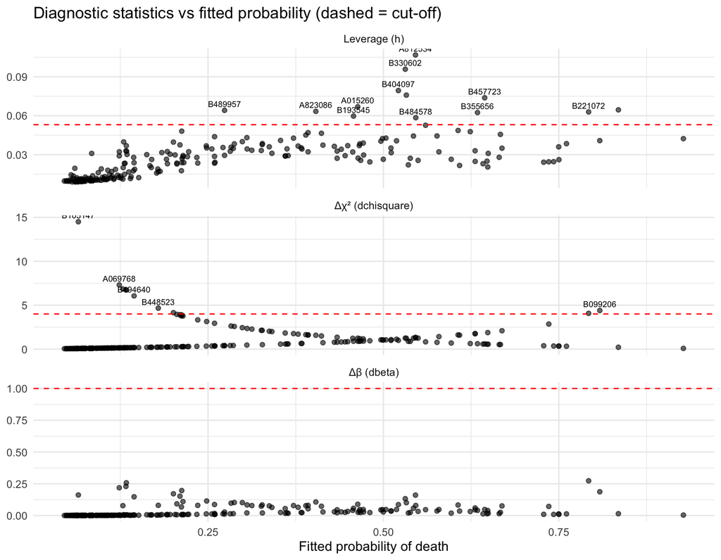

```r
diag_long <- diag %>%
  select(id, .fitted, leverage, dchisq, dbeta) %>%
  pivot_longer(c(leverage, dchisq, dbeta), names_to = "statistic") %>%
  mutate(cut = cutoffs[statistic],
         statistic = factor(statistic, c("leverage", "dchisq", "dbeta"),
                            c("Leverage (h)", "Δχ² (dchisquare)", "Δβ (dbeta)")))

ggplot(diag_long, aes(.fitted, value)) +
  geom_point(alpha = 0.6) +
  geom_hline(aes(yintercept = cut), linetype = "dashed", colour = "red") +
  geom_text(data = ~ filter(.x, value > cut), aes(label = id),
            size = 2.6, vjust = -0.6, check_overlap = TRUE) +
  facet_wrap(~ statistic, scales = "free_y", ncol = 1) +
  labs(x = "Fitted probability of death", y = NULL,
       title = "Diagnostic statistics vs fitted probability (dashed = cut-off)")
```

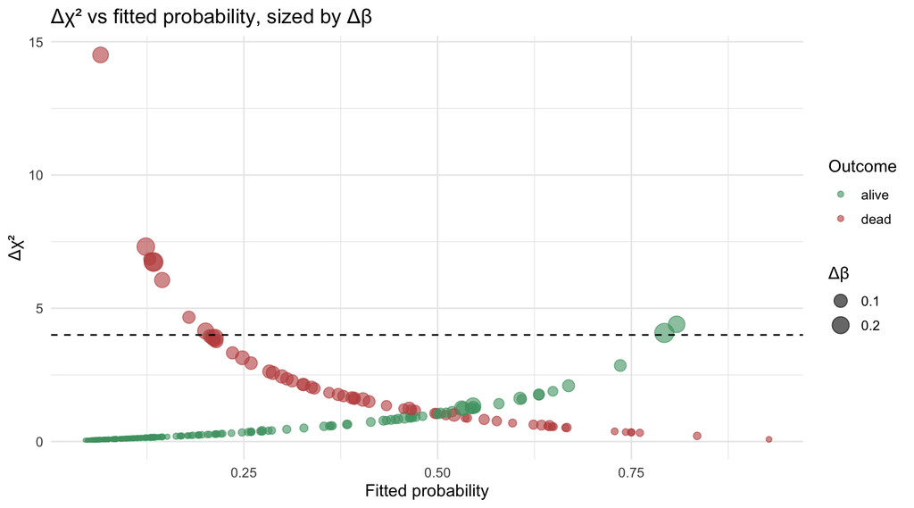

```r
ggplot(diag, aes(.fitted, dchisq, size = dbeta, colour = factor(outcome))) +
  geom_point(alpha = 0.6) +
  geom_hline(yintercept = 4, linetype = "dashed") +
  scale_colour_manual(values = c(alive = "#4C9F70", dead = "#C0504D"), name = "Outcome") +
  labs(x = "Fitted probability", y = "Δχ²", size = "Δβ",
       title = "Δχ² vs fitted probability, sized by Δβ")
```

**Interpretation.** The plots show the usual two arms. Points high on the left are patients who **died despite a low predicted risk**; points high on the right are patients who **survived despite a high predicted risk**. Points above the dashed lines are poorly fitted or influential.

## 6.3 Influential observations

```r
influential <- diag %>%
  mutate(high_leverage = leverage > cutoffs["leverage"],
         high_dchisq   = dchisq   > cutoffs["dchisq"],
         high_dbeta    = dbeta    > cutoffs["dbeta"],
         high_cooks    = .cooksd  > cutoffs["cooksd"],
         n_flags = high_leverage + high_dchisq + high_dbeta + high_cooks) %>%
  filter(n_flags > 0) %>%
  arrange(desc(dbeta))

influential %>%
  select(id, outcome, all_of(all.vars(formula(m_final))[-1]),
         fitted = .fitted, leverage, dchisq, dbeta, cooksd = .cooksd, n_flags) %>%
  mutate(across(where(is.double), ~ round(.x, 3))) %>%
  print(n = Inf)
```

```
# A tibble: 26 × 13
   id      outcome   wbc stroke_type referral sex     age fitted leverage dchisq
   <chr>   <fct>   <dbl> <fct>       <fct>    <fct> <dbl>  <dbl>    <dbl>  <dbl>
 1 B221072 alive    22.4 Haemorrhag… GP/Home  fema…    63  0.792    0.063  4.07
 2 B479532 dead      4.8 Haemorrhag… GP/Home  male     76  0.134    0.037  6.74
 3 B283597 dead     14.3 Ischaemic   GP/Home  male     29  0.133    0.033  6.74
 4 A069768 dead      5.8 Haemorrhag… GP/Home  male     60  0.123    0.029  7.31
 5 A012903 dead     12   Ischaemic   Hospital male     32  0.213    0.048  3.89
 6 B099206 alive    18.7 Haemorrhag… Hospital male     66  0.808    0.041  4.40
 7 B482104 dead     11.1 Haemorrhag… GP/Home  male     37  0.201    0.04   4.15
 8 B105147 dead      6.8 Ischaemic   GP/Home  fema…    51  0.065    0.011 14.5
 9 A812534 alive    23   Ischaemic   GP/Home  fema…    44  0.546    0.107  1.34
10 B098506 dead     10.1 Ischaemic   GP/Home  fema…    94  0.21     0.038  3.91
11 B494640 dead      7.3 Ischaemic   Hospital male     55  0.145    0.024  6.06
12 B330602 alive    19.4 Haemorrhag… GP/Home  fema…    24  0.531    0.096  1.25
13 B045768 dead      7.2 Ischaemic   Hospital fema…    83  0.248    0.035  3.14
14 B465069 dead      8.7 Ischaemic   Hospital male     68  0.214    0.028  3.77
15 A823086 dead     10.1 Ischaemic   Hospital fema…    94  0.404    0.063  1.58
16 B463535 alive    15.3 Ischaemic   Hospital male     81  0.533    0.076  1.23
17 A015260 dead     19.8 Ischaemic   GP/Home  fema…    59  0.463    0.067  1.24
18 B404097 dead     15.5 Haemorrhag… Hospital male     21  0.521    0.079  0.997
19 B448523 dead     10.7 Ischaemic   GP/Home  fema…    76  0.179    0.017  4.66
20 B484578 alive    17.7 Haemorrhag… GP/Home  male     58  0.546    0.058  1.28
21 B482936 dead      9.5 Ischaemic   GP/Home  fema…    66  0.129    0.011  6.85
22 B193545 alive    12.4 Haemorrhag… Hospital fema…    27  0.457    0.06   0.896
23 B457723 dead     18   Haemorrhag… Hospital male     24  0.644    0.074  0.596
24 B355656 dead     16.5 Haemorrhag… GP/Home  fema…    80  0.634    0.062  0.616
25 B489957 alive     8   Haemorrhag… Hospital fema…    27  0.274    0.064  0.402
26 B472708 dead     24.4 Haemorrhag… GP/Home  fema…    58  0.835    0.064  0.211
# ℹ 3 more variables: dbeta <dbl>, cooksd <dbl>, n_flags <int>
```

```r
tibble(criterion = c("Leverage > 2p/n", "Δχ² > 4", "Δβ > 1", "Cook's D > 4/n"),
       n_flagged = c(sum(influential$high_leverage), sum(influential$high_dchisq),
                     sum(influential$high_dbeta), sum(influential$high_cooks)))
```

```
# A tibble: 4 × 2
  criterion       n_flagged
  <chr>               <int>
1 Leverage > 2p/n        13
2 Δχ² > 4                10
3 Δβ > 1                  0
4 Cook's D > 4/n         15
```

### 6.3.1 Sensitivity analysis

The most influential patients are removed in a **sensitivity analysis only**: those flagged by Δβ > 1, or else the 5 with the largest Δβ. The odds ratios are then compared. **The main model keeps all patients.**

```r
drop_ids <- if (any(diag$dbeta > 1)) diag$id[diag$dbeta > 1] else
  diag %>% slice_max(dbeta, n = 5) %>% pull(id)
drop_ids
```

```
[1] "B221072" "B479532" "B283597" "A069768" "A012903"
attr(,"format.stata")
[1] "%8s"
```

```r
m_sens <- update(m_final, data = filter(stroke, !id %in% drop_ids))

full_join(
  tidy(m_final, exponentiate = TRUE, conf.int = TRUE) %>%
    transmute(term, OR_all = estimate, CI_all = sprintf("%.2f–%.2f", conf.low, conf.high)),
  tidy(m_sens, exponentiate = TRUE, conf.int = TRUE) %>%
    transmute(term, OR_sens = estimate, CI_sens = sprintf("%.2f–%.2f", conf.low, conf.high)),
  by = "term") %>%
  filter(term != "(Intercept)") %>%
  mutate(pct_change = round(100 * (OR_sens - OR_all) / OR_all, 1),
         across(c(OR_all, OR_sens), ~ round(.x, 3)))
```

```
# A tibble: 5 × 6
  term                    OR_all CI_all    OR_sens CI_sens   pct_change
  <chr>                    <dbl> <chr>       <dbl> <chr>          <dbl>
1 wbc                      1.20  1.10–1.33   1.26  1.14–1.41        5.3
2 stroke_typeHaemorrhagic  2.56  1.24–5.34   2.54  1.17–5.54       -1.1
3 referralGP/Home          0.393 0.19–0.80   0.359 0.17–0.77       -8.6
4 sexfemale                1.23  0.62–2.48   1.69  0.81–3.61       37.1
5 age                      1.02  0.99–1.04   1.03  1.00–1.06        1
```

**Interpretation.** Without the 5 most influential patients, the ORs for WBC, stroke type and referral change by less than about 10% and keep the same direction and significance. **The main conclusions do not depend on a few patients.** The sex OR moves more, but it is non-significant in both fits and its CI includes 1. Influential patients should be checked against the source records, not deleted.

## 6.4 Discrimination: ROC curve and AUC

```r
roc_final <- roc(stroke$dead, fitted(m_final), quiet = TRUE)
auc_ci <- ci.auc(roc_final)
auc_ci
```

```
95% CI: 0.7427-0.8592 (DeLong)
```

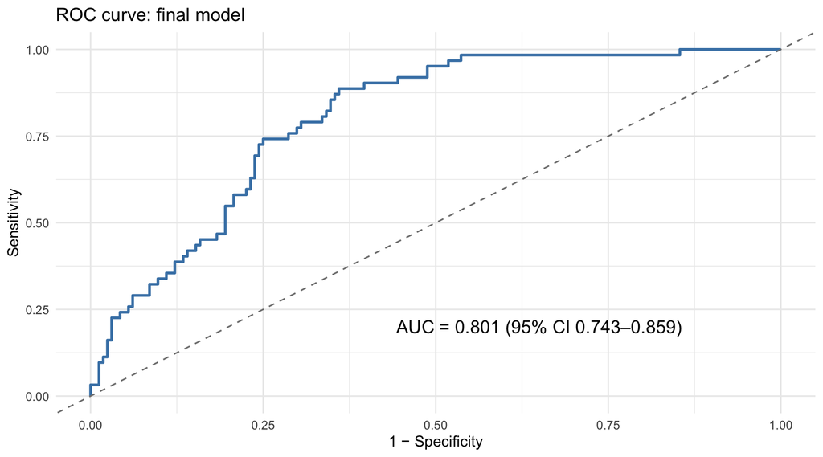

```r
ggroc(roc_final, legacy.axes = TRUE, colour = "steelblue", linewidth = 1) +
  geom_abline(linetype = "dashed", colour = "grey50") +
  annotate("text", x = 0.65, y = 0.2, size = 5,
           label = sprintf("AUC = %.3f (95%% CI %.3f–%.3f)", auc_ci[2], auc_ci[1], auc_ci[3])) +
  labs(title = "ROC curve: final model", x = "1 − Specificity", y = "Sensitivity")
```

**Interpretation.** AUC = 0.801. A randomly chosen patient who died has a 80% chance of a higher predicted risk than a randomly chosen survivor. This is excellent discrimination by Hosmer–Lemeshow’s guide (0.7–0.8 acceptable, 0.8–0.9 excellent). It is not higher because the strongest predictor, GCS, was left out on purpose.

## 6.5 Accuracy: classification tables

```r
youden <- coords(roc_final, "best", best.method = "youden",
                 ret = c("threshold", "sensitivity", "specificity"))

classify <- function(cut) {
  pred <- factor(if_else(fitted(m_final) >= cut, "dead", "alive"), c("alive", "dead"))
  tab  <- table(Predicted = pred, Observed = stroke$outcome)
  TP <- tab["dead", "dead"]; TN <- tab["alive", "alive"]
  FP <- tab["dead", "alive"]; FN <- tab["alive", "dead"]
  list(table = tab,
       metrics = tibble(cut_off = round(cut, 3),
                        accuracy = (TP + TN) / sum(tab),
                        sensitivity = TP / (TP + FN), specificity = TN / (TN + FP),
                        PPV = TP / (TP + FP), NPV = TN / (TN + FN)))
}
c05 <- classify(0.5)
cyj <- classify(youden$threshold[1])

c05$table
```

```
         Observed
Predicted alive dead
    alive   145   40
    dead     19   22
```

```r
cyj$table
```

```
         Observed
Predicted alive dead
    alive   105    7
    dead     59   55
```

```r
acc_tbl <- bind_rows(`0.5` = c05$metrics, Youden = cyj$metrics, .id = "rule") %>%
  mutate(across(accuracy:NPV, ~ round(.x, 3)))
acc_tbl
```

```
# A tibble: 2 × 7
  rule   cut_off accuracy sensitivity specificity   PPV   NPV
  <chr>    <dbl>    <dbl>       <dbl>       <dbl> <dbl> <dbl>
1 0.5      0.5      0.739       0.355       0.884 0.537 0.784
2 Youden   0.198    0.708       0.887       0.64  0.482 0.938
```

**Interpretation.** At the 0.5 cut-off the accuracy is 73.9%, but the sensitivity is only 35.5%. Deaths are the minority (27%), so few patients reach a predicted risk of 0.5. The Youden cut-off (0.198) trades some specificity for higher sensitivity (88.7%), with an accuracy of 70.8%. Accuracy alone is misleading when the outcome is unbalanced, so read it together with sensitivity, specificity and AUC.

# 7 Present

## 7.1 Univariable logistic regression: log-odds and odds ratios

```r
uni_data <- stroke %>% select(outcome, all_of(candidates))
uni_beta <- tbl_uvregression(uni_data, method = glm, y = outcome,
                             method.args = list(family = binomial),
                             exponentiate = FALSE, label = var_labels,
                             hide_n = TRUE) %>%
  modify_column_hide(p.value)
uni_or <- tbl_uvregression(uni_data, method = glm, y = outcome,
                           method.args = list(family = binomial),
                           exponentiate = TRUE, label = var_labels) %>%
  add_global_p() %>% bold_p(t = 0.25)
tbl_merge(list(uni_beta, uni_or),
          tab_spanner = c("**Log-odds (β)**", "**Crude odds ratio**")) %>%
  modify_footnote_header("p-value: likelihood ratio test; bold = p < 0.25 (screening threshold)",
                         columns = p.value_2, replace = TRUE)
```

Table 2: Table 2. Univariable (simple) logistic regression: β (log-odds) and crude OR with 95% CI

| **Characteristic** | **Log-odds (β)** **log(OR)** | **Log-odds (β)** **95% CI** | **Crude odds ratio** **N** | **Crude odds ratio** **OR** | **Crude odds ratio** **95% CI** | **Crude odds ratio** **p-value**<sup>1</sup> |
| --- | --- | --- | --- | --- | --- | --- |
| Age (years) | 0.00 | -0.02, 0.02 | 226 | 1.00 | 0.98, 1.02 | 0.8 |
| Glasgow Coma Scale | -0.63 | -0.81, -0.49 | 226 | 0.53 | 0.44, 0.61 | <0.001 |
| Systolic BP (mmHg) | 0.00 | -0.01, 0.01 | 226 | 1.00 | 0.99, 1.01 | 0.8 |
| Diastolic BP (mmHg) | 0.01 | -0.01, 0.02 | 226 | 1.01 | 0.99, 1.02 | 0.4 |
| Heart rate (bpm) | 0.01 | 0.00, 0.03 | 226 | 1.01 | 1.00, 1.03 | 0.061 |
| Haemoglobin (g/dL) | -0.12 | -0.26, 0.01 | 226 | 0.88 | 0.77, 1.01 | 0.066 |
| Platelet (×10⁹/L) | 0.00 | -0.01, 0.00 | 226 | 1.00 | 1.0, 1.00 | 0.5 |
| White cell count (×10⁹/L) | 0.22 | 0.13, 0.31 | 226 | 1.24 | 1.14, 1.36 | <0.001 |
| Sodium (mmol/L) | 0.07 | 0.01, 0.14 | 226 | 1.07 | 1.01, 1.15 | 0.016 |
| Potassium (mmol/L) | -0.05 | -0.58, 0.46 | 226 | 0.95 | 0.56, 1.59 | 0.8 |
| Capillary blood sugar (mmol/L) | 0.04 | -0.02, 0.10 | 226 | 1.04 | 0.98, 1.10 | 0.2 |
| Urea (mmol/L) | 0.02 | -0.03, 0.07 | 226 | 1.02 | 0.97, 1.07 | 0.4 |
| Sex |  |  | 226 |  |  | 0.2 |
| male | — | — |  | — | — |  |
| female | 0.43 | -0.17, 1.0 |  | 1.53 | 0.84, 2.84 |  |
| Malay ethnicity |  |  | 226 |  |  | 0.6 |
| no | — | — |  | — | — |  |
| yes | -0.30 | -1.4, 0.90 |  | 0.74 | 0.25, 2.46 |  |
| Married |  |  | 226 |  |  | 0.3 |
| no | — | — |  | — | — |  |
| yes | -0.54 | -1.5, 0.43 |  | 0.58 | 0.23, 1.54 |  |
| Hypertension |  |  | 226 |  |  | 0.5 |
| no | — | — |  | — | — |  |
| yes | 0.23 | -0.40, 0.90 |  | 1.26 | 0.67, 2.46 |  |
| Diabetes |  |  | 226 |  |  | 0.8 |
| no | — | — |  | — | — |  |
| yes | 0.07 | -0.53, 0.66 |  | 1.07 | 0.59, 1.94 |  |
| Dyslipidaemia |  |  | 226 |  |  | 0.022 |
| no | — | — |  | — | — |  |
| yes | -1.3 | -2.7, -0.17 |  | 0.28 | 0.07, 0.85 |  |
| Referral source |  |  | 226 |  |  | <0.001 |
| Hospital | — | — |  | — | — |  |
| GP/Home | -1.4 | -2.0, -0.80 |  | 0.24 | 0.13, 0.45 |  |
| Stroke type |  |  | 226 |  |  | <0.001 |
| Ischaemic | — | — |  | — | — |  |
| Haemorrhagic | 1.6 | 1.0, 2.3 |  | 5.07 | 2.74, 9.59 |  |

<sup>1</sup> p-value: likelihood ratio test; bold = p < 0.25 (screening threshold)  
Abbreviations: CI = Confidence Interval, OR = Odds Ratio

## 7.2 Multivariable logistic regression: log-odds and adjusted odds ratios

```r
mv_beta <- tbl_regression(m_final, exponentiate = FALSE, label = var_labels,
                          intercept = TRUE) %>%
  modify_column_hide(p.value)
mv_or <- tbl_regression(m_final, exponentiate = TRUE, label = var_labels,
                        intercept = TRUE) %>%
  add_global_p(keep = TRUE) %>% bold_p()
tbl_merge(list(mv_beta, mv_or),
          tab_spanner = c("**Log-odds (β)**", "**Adjusted odds ratio**"))
```

Table 3: Table 3. Multivariable logistic regression (final model, no interaction): β (log-odds) and adjusted OR with 95% CI

| **Characteristic** | **Log-odds (β)** **log(OR)** | **Log-odds (β)** **95% CI** | **Adjusted odds ratio** **OR** | **Adjusted odds ratio** **95% CI** | **Adjusted odds ratio** **p-value** |
| --- | --- | --- | --- | --- | --- |
| (Intercept) | -4.1 | -6.3, -2.0 | 0.02 | 0.00, 0.14 | <0.001 |
| White cell count (×10⁹/L) | 0.18 | 0.09, 0.28 | 1.20 | 1.10, 1.33 | <0.001 |
| Stroke type |  |  |  |  | 0.011 |
| Ischaemic | — | — | — | — |  |
| Haemorrhagic | 0.94 | 0.21, 1.7 | 2.57 | 1.24, 5.34 | 0.011 |
| Referral source |  |  |  |  | 0.010 |
| Hospital | — | — | — | — |  |
| GP/Home | -0.93 | -1.7, -0.22 | 0.39 | 0.19, 0.80 | 0.010 |
| Sex |  |  |  |  | 0.6 |
| male | — | — | — | — |  |
| female | 0.21 | -0.48, 0.91 | 1.23 | 0.62, 2.48 | 0.6 |
| Age (years) | 0.02 | -0.01, 0.04 | 1.02 | 0.99, 1.04 | 0.2 |

Abbreviations: CI = Confidence Interval, OR = Odds Ratio

```r
lrt_terms <- drop1(m_final, test = "LRT") %>% as.data.frame() %>%
  rownames_to_column("variable") %>% filter(variable != "<none>") %>%
  select(variable, LRT_chisq = LRT, LRT_p = `Pr(>Chi)`)
tidy(m_final, conf.int = TRUE) %>%
  transmute(term,
            `β (95% CI)`  = sprintf("%.3f (%.3f, %.3f)", estimate, conf.low, conf.high),
            SE = round(std.error, 3),
            `OR (95% CI)` = if_else(term == "(Intercept)", "—",
                                    sprintf("%.3f (%.3f, %.3f)", exp(estimate),
                                            exp(conf.low), exp(conf.high))),
            `Wald p` = format.pval(p.value, digits = 3, eps = 0.001)) %>%
  knitr::kable()
lrt_terms %>% mutate(across(where(is.numeric), ~ signif(.x, 3))) %>% knitr::kable()
```

Table 4: Table 3b. Final model from broom::tidy() with LRT for removing each term

| term | β (95% CI) | SE | OR (95% CI) | Wald p |
| --- | --- | --- | --- | --- |
| (Intercept) | -4.053 (-6.276, -1.991) | 1.088 | — | <0.001 |
| wbc | 0.183 (0.091, 0.282) | 0.049 | 1.201 (1.095, 1.326) | <0.001 |
| stroke_typeHaemorrhagic | 0.942 (0.214, 1.675) | 0.371 | 2.565 (1.239, 5.339) | 0.0112 |
| referralGP/Home | -0.935 (-1.653, -0.224) | 0.363 | 0.393 (0.191, 0.800) | 0.0100 |
| sexfemale | 0.209 (-0.480, 0.908) | 0.352 | 1.232 (0.619, 2.478) | 0.5530 |
| age | 0.017 (-0.007, 0.042) | 0.013 | 1.017 (0.993, 1.043) | 0.1724 |

| variable | LRT_chisq | LRT_p |
| --- | --- | --- |
| wbc | 15.800 | 7.12e-05 |
| stroke_type | 6.420 | 1.13e-02 |
| referral | 6.620 | 1.01e-02 |
| sex | 0.353 | 5.52e-01 |
| age | 1.900 | 1.68e-01 |

## 7.3 Crude vs adjusted

```r
final_vars <- all.vars(formula(m_final))[-1]
crude_tbl <- stroke %>% select(outcome, all_of(final_vars)) %>%
  tbl_uvregression(method = glm, y = outcome,
                   method.args = list(family = binomial),
                   exponentiate = TRUE, label = var_labels, hide_n = TRUE)
adj_tbl <- tbl_regression(m_final, exponentiate = TRUE, label = var_labels)
tbl_merge(list(crude_tbl, adj_tbl), tab_spanner = c("**Crude OR**", "**Adjusted OR**"))
```

Table 5: Table 4. Crude and adjusted odds ratios for the variables in the final model

| **Characteristic** | **Crude OR** **OR** | **Crude OR** **95% CI** | **Crude OR** **p-value** | **Adjusted OR** **OR** | **Adjusted OR** **95% CI** | **Adjusted OR** **p-value** |
| --- | --- | --- | --- | --- | --- | --- |
| White cell count (×10⁹/L) | 1.24 | 1.14, 1.36 | <0.001 | 1.20 | 1.10, 1.33 | <0.001 |
| Stroke type |  |  |  |  |  |  |
| Ischaemic | — | — |  | — | — |  |
| Haemorrhagic | 5.07 | 2.74, 9.59 | <0.001 | 2.57 | 1.24, 5.34 | 0.011 |
| Referral source |  |  |  |  |  |  |
| Hospital | — | — |  | — | — |  |
| GP/Home | 0.24 | 0.13, 0.45 | <0.001 | 0.39 | 0.19, 0.80 | 0.010 |
| Sex |  |  |  |  |  |  |
| male | — | — |  | — | — |  |
| female | 1.53 | 0.84, 2.84 | 0.2 | 1.23 | 0.62, 2.48 | 0.6 |
| Age (years) | 1.00 | 0.98, 1.02 | 0.8 | 1.02 | 0.99, 1.04 | 0.2 |

Abbreviations: CI = Confidence Interval, OR = Odds Ratio

## 7.4 Model fit and performance

```r
tribble(
  ~Measure, ~Value,
  "Deviance (df)", sprintf("%.2f (%d)", deviance(m_final), df.residual(m_final)),
  "AIC", sprintf("%.2f", AIC(m_final)),
  "Model LRT vs null", sprintf("G = %.2f, df = %d, p %s", g_lrt$Deviance[2], g_lrt$Df[2],
                               format.pval(g_lrt$`Pr(>Chi)`[2], eps = 0.001)),
  "Hosmer–Lemeshow, g = 10", sprintf("Ĉ = %.3f, df = %d, p = %.4f", hl$C_hat[1], hl$df[1], hl$p_value[1]),
  "Hosmer–Lemeshow, g = 8",  sprintf("Ĉ = %.3f, df = %d, p = %.4f", hl$C_hat[2], hl$df[2], hl$p_value[2]),
  "Hosmer–Lemeshow, g = 6",  sprintf("Ĉ = %.3f, df = %d, p = %.4f", hl$C_hat[3], hl$df[3], hl$p_value[3]),
  "AUC (95% CI)", sprintf("%.3f (%.3f–%.3f)", auc_ci[2], auc_ci[1], auc_ci[3]),
  "Accuracy / Sens / Spec at 0.5",
    sprintf("%.1f%% / %.1f%% / %.1f%%", 100*acc_tbl$accuracy[1], 100*acc_tbl$sensitivity[1], 100*acc_tbl$specificity[1]),
  sprintf("Accuracy / Sens / Spec at Youden (%.3f)", acc_tbl$cut_off[2]),
    sprintf("%.1f%% / %.1f%% / %.1f%%", 100*acc_tbl$accuracy[2], 100*acc_tbl$sensitivity[2], 100*acc_tbl$specificity[2]),
  "Influential observations (Δβ > 1)", as.character(sum(diag$dbeta > 1))
) %>% knitr::kable()
```

Table 6: Table 5. Goodness of fit, discrimination and classification of the final model

| Measure | Value |
| --- | --- |
| Deviance (df) | 214.17 (220) |
| AIC | 226.17 |
| Model LRT vs null | G = 51.39, df = 5, p < 0.001 |
| Hosmer–Lemeshow, g = 10 | Ĉ = 13.149, df = 8, p = 0.1068 |
| Hosmer–Lemeshow, g = 8 | Ĉ = 14.068, df = 6, p = 0.0289 |
| Hosmer–Lemeshow, g = 6 | Ĉ = 13.638, df = 4, p = 0.0085 |
| AUC (95% CI) | 0.801 (0.743–0.859) |
| Accuracy / Sens / Spec at 0.5 | 73.9% / 35.5% / 88.4% |
| Accuracy / Sens / Spec at Youden (0.198) | 70.8% / 88.7% / 64.0% |
| Influential observations (Δβ > 1) | 0 |

## 7.5 Interpretation of the final model

Each adjusted odds ratio holds the other variables in the model constant:

- **White cell count:** each 1 × 10⁹/L increase is associated with an adjusted OR of 1.20 (95% CI 1.10, 1.33; p < 0.001) for death.
- **Stroke type:** haemorrhagic stroke has adjusted OR 2.57 (95% CI 1.24, 5.34; p = 0.011) compared with ischaemic stroke.
- **Referral source:** GP/Home referral has adjusted OR 0.39 (95% CI 0.19, 0.80; p = 0.010) compared with referral from another hospital. Hospital transfers are likely to be more severe cases.
- **Sex:** female vs male adjusted OR 1.23 (95% CI 0.62, 2.48; p = 0.553).
- **Age:** per year, adjusted OR 1.02 (95% CI 0.99, 1.04; p = 0.172).

# 8 Publish

This report was produced from `stroke_rreaapp.qmd` and rendered with Quarto to a self-contained HTML file (`reports/stroke_rreaapp.html`). The raw data file (`data/stroke-fatality-cooked2.dta`) was not changed. Every record was kept in the main analysis. The workflow and its decisions are documented in `implementation.md`, and the working rules in `AGENTS.md`.

**Limitations.**

- Teaching dataset with values modified by the author.
- Single centre, n = 226.
- GCS was deliberately left out, so the model is for estimating associations, not for prediction.
- No interaction terms were considered (by design). The chapter shows a stroke type × referral interaction that this main-effect model does not include.